# Examen, OPT.R

Claudio Bustos Hodges

2022-12-05

### **VICTIMIZACIÓN Y PERCEPCIÓN DE LA DELINCUENCIA EN LA MACROZONA CENTRO SUR Y MACROZONA SUR DE CHILE**

##### **Abstrac**

La victimización y percepción de la delincuencia en nuestro país resulta una problemática que, históricamente, ha estado en la palestra en el acontecer nacional, constituyendo así una temática que no resulta ajena a ninguna persona que habita el territorio. Ante esto, el presente trabajo busca dar cuenta de la victimización -específicamente considerar ser víctima de algún delito los próximos doce meses- y percepción que tienen mujeres y hombres de las macrozonas centro sur, y sur, con tramos etarios que van desde entre los 20 a 39 años, y 40 a 69 años respectivamente, acerca de la delincuencia imperante en aquellas zonas geográficas del país.

##### **Introducción**

La delincuencia constituye un fenómeno social inherente a cualquier sociedad, con medidas y formas de tratarla que varían, pero que encuentran un único fin: lograr mantenerla bajo control, con el propósito de brindar seguridad a los miembros de una sociedad que, de manera persistente y casi natural, apelan por la búsqueda de aquella seguridad que remite a una “expresión de una necesidad vital del ser humano” (Burgos y Tudela, 2002:475). Es frente a situaciones delictuales -siendo víctimas, testigos, así como conocedores del fenómeno como tal- es que se manifiesta y se forma, en la persona misma, diversas percepciones, opiniones, y modos de enfrentarse a este. Ante esto es que surge, tal como lo señala la propia teoría de la victimización, “mayores niveles de temor a la delincuencia” (Paydar y Kamani, 2015:180), logrando incluso, formarse diversas perspectivas y escenarios en los cuales se supone, o espera, la delincuencia afectase de manera directa a la persona como tal.

Es en base a lo recientemente señalado, que este trabajo da cuenta de cómo es que la victimización y percepción que se tiene de la delincuencia en nuestro país, varía y se ve afectada por diversos factores, siendo los más importantes y fundamentales, aquellos que remiten al sexo, edad y zona geográfica que se habite.

##### **Análisis**

El análisis de la base de datos de la 18° Encuesta Nacional Urbana de Seguridad Ciudadana (ENUSC) llevada a cabo por el INE el año 2021, comenzó con la selección de las siguientes variables: victimización (P4_1_1), percepción de la delincuencia (P1_1_1), edad (rph_edad), sexo (rph_sexo) y región (enc_region). Se incurrió en el filtro y recodificación de estas, buscando trabajar con población -masculina y femenina- de las regiones del Maule, Ñuble, BioBío y Araucanía (Macrozona Centro Sur); y de las regiones de Los Ríos, Los Lagos, Aysén y Magallanes (Macrozona Sur). Cabe mencionar, que la recodificación en macrozonas fue en base a la distribución que se señala en la página https://www.prochile.gob.cl.De igual forma, las edades de aquella población fueron recodificadas en dos grupos: 20 a 39 años, y 40 a 69 años. Dentro del proceso de recodificación, las variables fueron renombradas, con la intención de facilitar el posterior análisis de estas.

Así mismo, se trabajó en la creación de un objeto encuesta (denominado ENUSC), con la finalidad de realizar cálculos para muestras complejas, además de lograr obtener las proporciones de las variables anteriormente señaladas. El análisis de las variables y las relaciones existentes entre ellas, fue en base a un nivel de confianza del 99% (0.99) y con un 1% de nivel de significancia, esto dada la pretensión de que las estimaciones hechas incluyeran de mejor manera el parámetro poblacional, y asumiendo ,de igual forma, que el nivel de confianza escogido (99%) para la realización del análisis implica la cierta pérdida de precisión en los cálculos realizados. Tambíen, el análisis que aquí se presenta buscó establecer las relaciones que se dan entre las variables sociodemográficas escogidas (sexo, edad, región) con aquellas variables de percepción de la delincuencia (P1_1_1) y de victimización (P4_1_1). Estos análisis entre variables se encuentra representado en los siguientes gráficos y tablas de contingencia:

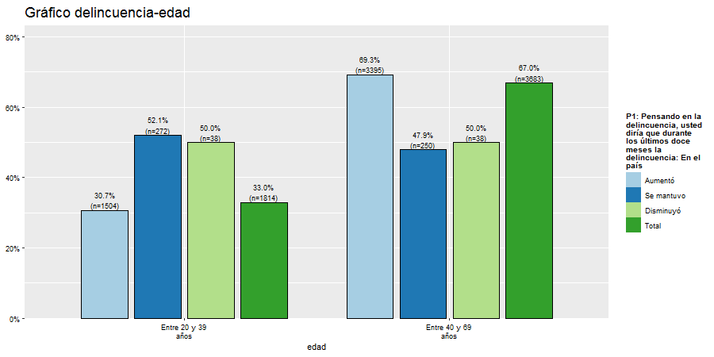

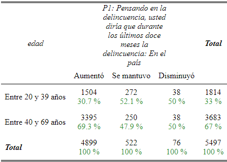

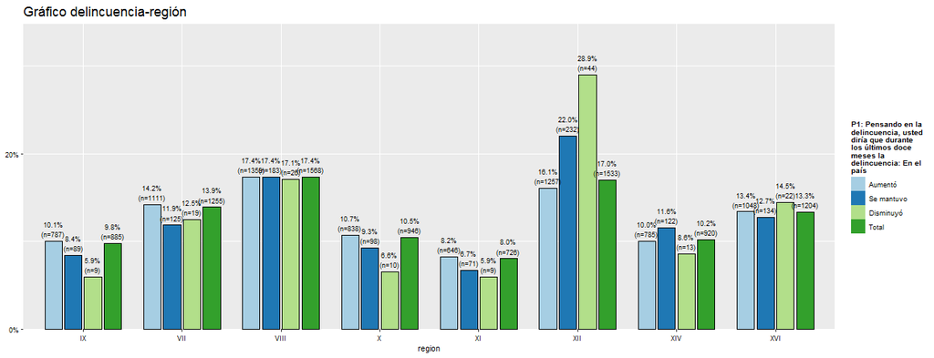

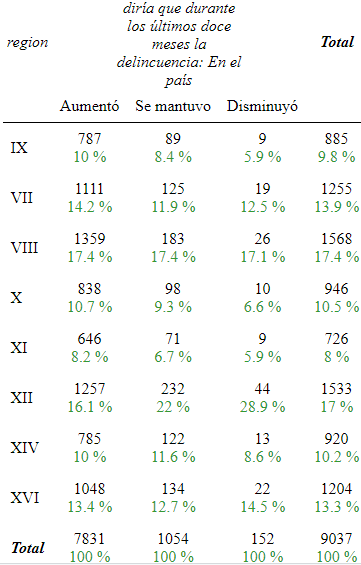

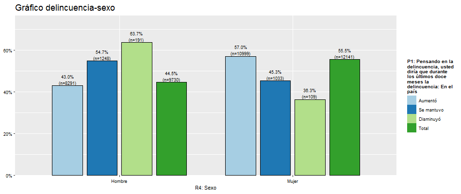

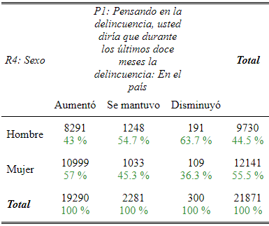

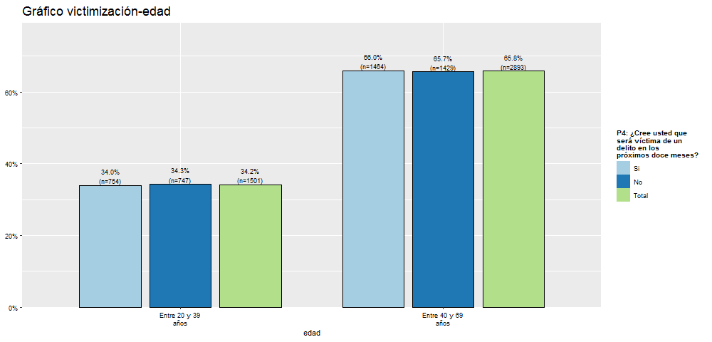

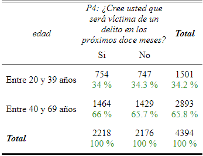

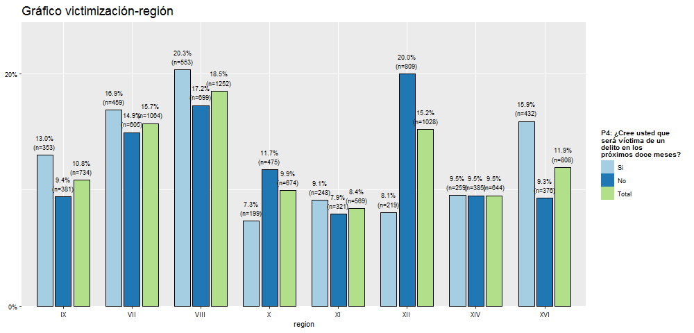

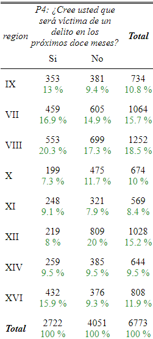

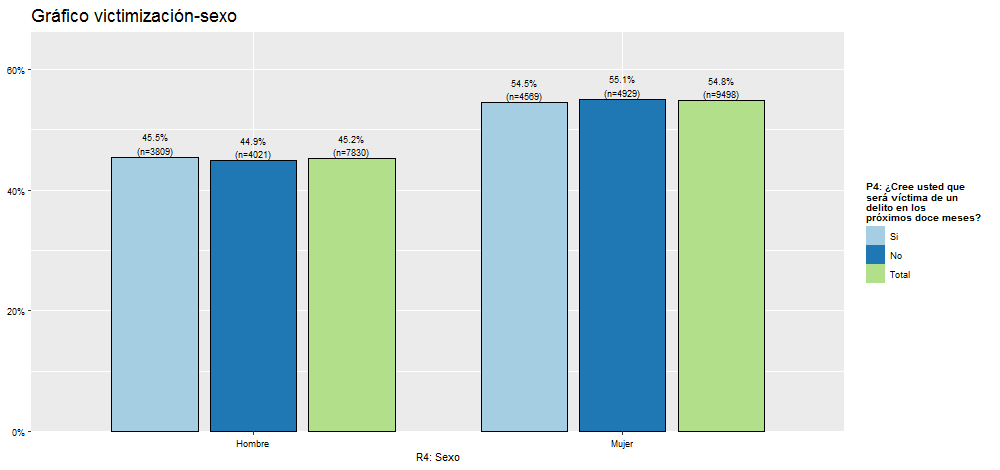

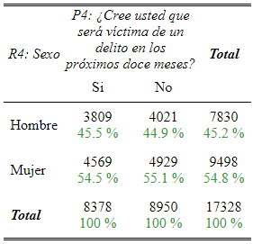

##### **Bibliografía**

- BURGOS, J., TUDELA, P. (2002). Seguridad ciudadana en Chile: Los desafíos de la participación y la modernización para una política pública. En: Seguridad ciudadana: espejismo o realidad. FLACSO y OPS/OMS. Quito, Ecuador.
- Pydar, M.,Asal, K. “El temor a la delincuencia y la percepción de inseguridad en el entorno urbano.” Argos, vol. 32, no. 63, 2015, pp. 179-195.